# Compscix-415-2-Homework 7

Kannu Priya Arora

Mar 17, 2018

## House Prices prediction competition on Kaggle

### Exercise 1

*Load the train.csv dataset into R. How many observations and columns are there?*

No of observations - 1460 No of columns - 81

```r
data_csv <- read_csv(file = 'D:/Kannu Priya/DataScience/compscix-415-2-assignments/assignment 8/train.csv')
```

### Exercise 2

*Our first step is to randomly split the data into train and test datasets. We will use a 70/30 split. There is an R package that will do the split for you, but let’s get some more practice with R and do it ourselves by filling in the blanks in the code below.*

```r
# When taking a random sample, it is often useful to set a seed so that your work is reproducible.
# Setting a seed will guarantee that the same random sample will be generated every time,
# so long as you always set the same seed beforehand

set.seed(29283)

# This data already has an Id column which we can make use of.
# Let's create our training set using sample_frac. Fill in the blank.
train_set <- data_csv %>% sample_frac(0.7)

# let's create our testing set using the Id column. Fill in the blanks.
test_set <- data_csv %>% filter(!( Id %in% train_set$Id))
```

### Exercise 3

*Our target is called SalePrice. First, we can fit a simple regression model consisting of only the intercept (the average of SalePrice). Fit the model and then use the broom package to*

• *take a look at the coefficient* - 182176

• *compare the coefficient to the average value of SalePrice, and* - coefficient and average SalePrice is same

• *take a look at the R-squared.* - R squared is 0 as there is no variation and model is straight fit

*Use the code below and fill in the blanks.*

```r
# Fit a model with intercept only
mod_0 <- lm(SalePrice ~ 1, data = train_set)

# Double-check that the average SalePrice is equal to our model's coefficient
(mean(train_set$SalePrice))
```

```
## [1] 182176
```

```r
tidy(mod_0)
```

```
##          term estimate std.error statistic p.value
## 1 (Intercept)   182176  2492.072  73.10222       0
```

```r
# Check the R-squared
glance(mod_0)
```

```
##   r.squared adj.r.squared    sigma statistic p.value df    logLik      AIC
## 1         0             0 79668.37        NA      NA  1 -12983.57 25971.13
##        BIC     deviance df.residual
## 1 25980.99 6.480338e+12        1021
```

### Exercise 4

*Now fit a linear regression model using GrLivArea, OverallQual, and Neighborhood as the features.*

• *What kind of relationship will these features have with our target?*

• *Can the relationship be estimated linearly?*

• *Are these good features, given the problem we are trying to solve?*

Neighborhood on other hand shows high variation accross cities. For Brookside (BrkSide), as we can see in last histogram, the sales vary at large scale.

All three are good features to start fitting the model.

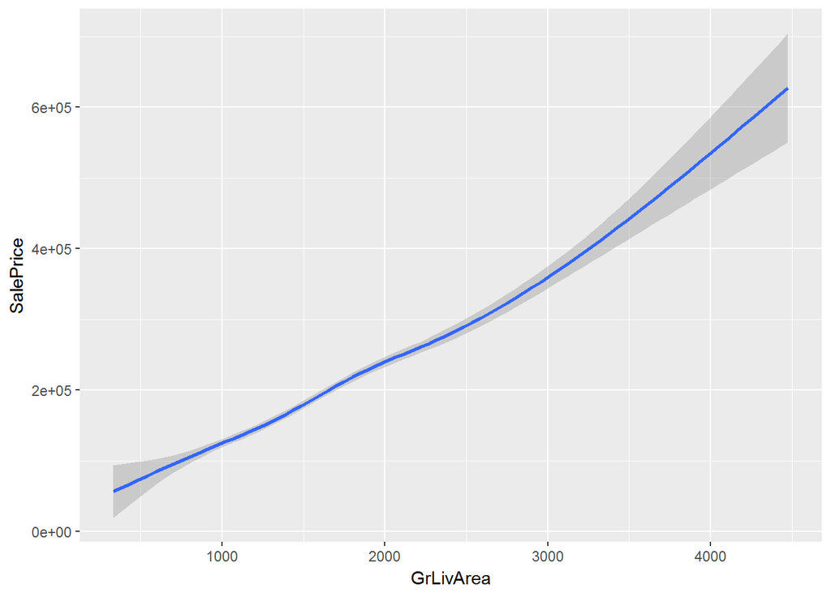

```r
train_set %>% ggplot(mapping = aes(GrLivArea, SalePrice))+ geom_smooth()
```

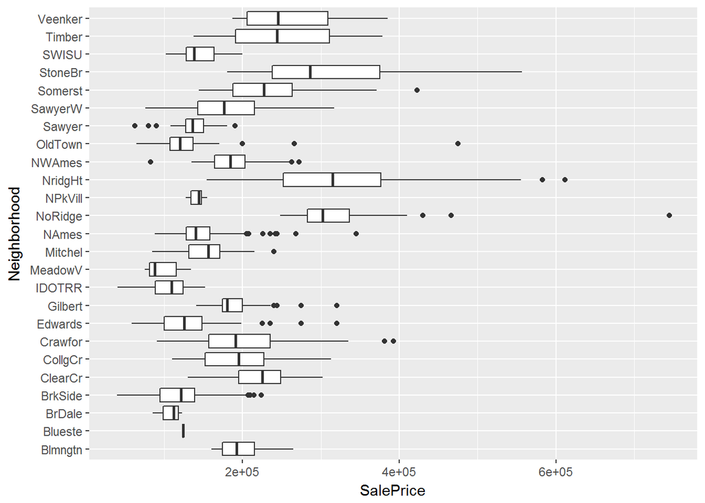

```r
train_set %>% ggplot(mapping = aes(Neighborhood, SalePrice))+ geom_boxplot() + coord_flip()
```

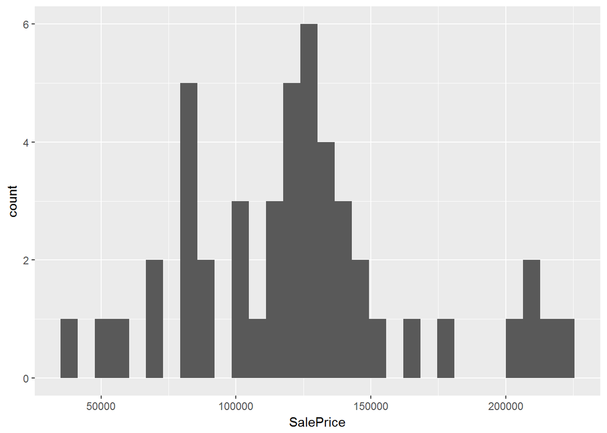

```r
train_set %>% filter(Neighborhood == 'BrkSide') %>% ggplot (aes(SalePrice)) + geom_histogram()
```

*After fitting the model, output the coefficients and the R-squared using the broom package.* *Answer these questions:*

• *How would you interpret the coefficients on GrLivArea and OverallQual?*

• *How would you interpret the coefficient on NeighborhoodBrkSide?*

Mean Sale price difference between the BrkSide(Brookside) and base city - Blmngtn (Bloomington Heights) is -14064.37 with Brookside being lower in sale price.

• *Are the features significant?*

The p-value for first two features - GrLivArea and OverallQual is almost 0 and we can thus say they are significant for predicting Sale Price outcome. For NeighborhoodBrkSide, p-value is greater than 0.05 and thus statistically not a significant predictor for SalePrice.

• *Are the features practically significant?*

GrLivArea - Above grade (ground) living area square feet. The feature is possible depiction of ground level surface area of the houses as a common preference of home buyers. While there is correlation, there are other factors such as lot size that may have stronger significance for prediction.

OverallQual rates the overall material and finish of the house. This can be symbolic of condition and quality of house and thus a logical feature.

Neighborhood generally varies in range for house prices. If it was a classifier problem statement where the desired output is whether the house will be high, medium or low in Sale Price, then Neighborhood might be stronger feature. It is hard to predict sale price of all houses in a particular neighborhood by ignoring all other features.

• *Is the model a good fit (to the training set)?*

Adjusted R-squared value of greater than 0.8 shows a very good fit for training set.

```r
# Fit a model with intercept only
mod_mult_0 <- lm(SalePrice ~ GrLivArea + OverallQual + Neighborhood, data = train_set)
tidy(mod_mult_0)
```

```
##                   term     estimate    std.error  statistic      p.value
## 1          (Intercept) -45017.87483 12933.341808 -3.4807612 5.216927e-04
## 2            GrLivArea     62.77735     3.006033 20.8837885 1.337222e-80
## 3          OverallQual  21692.23178  1353.714104 16.0242342 1.389020e-51
## 4  NeighborhoodBlueste -38288.88063 36531.907177 -1.0480942 2.948497e-01
## 5   NeighborhoodBrDale -43314.05372 14524.693991 -2.9820975 2.932566e-03
## 6  NeighborhoodBrkSide -14064.37052 11318.850018 -1.2425618 2.143221e-01
## 7  NeighborhoodClearCr  27839.00662 13561.346871  2.0528202 4.035110e-02
## 8  NeighborhoodCollgCr   4297.67432 10372.304467  0.4143413 6.787135e-01
## 9  NeighborhoodCrawfor   7423.05573 11371.511784  0.6527765 5.140512e-01
## 10 NeighborhoodEdwards -15284.11495 10994.287187 -1.3901870 1.647830e-01
## 11 NeighborhoodGilbert  -8357.55930 10894.173472 -0.7671586 4.431692e-01
## 12  NeighborhoodIDOTRR -32689.43085 12603.712743 -2.5936350 9.636216e-03
## 13 NeighborhoodMeadowV -14446.06504 14190.148622 -1.0180348 3.089089e-01
## 14 NeighborhoodMitchel   1922.31487 11788.608170  0.1630655 8.705000e-01
## 15   NeighborhoodNAmes  -7719.67883 10375.956174 -0.7439969 4.570540e-01
## 16 NeighborhoodNoRidge  47685.16790 12567.432633  3.7943444 1.569690e-04
## 17 NeighborhoodNPkVill -20240.71145 16548.664867 -1.2231024 2.215806e-01
## 18 NeighborhoodNridgHt  63872.80848 10880.456671  5.8704161 5.917964e-09
## 19  NeighborhoodNWAmes -12279.33299 11047.502893 -1.1115030 2.666204e-01
## 20 NeighborhoodOldTown -36107.07577 10849.170903 -3.3280954 9.064637e-04
## 21  NeighborhoodSawyer  -4121.92502 11252.369778 -0.3663162 7.142070e-01
## 22 NeighborhoodSawyerW  -5391.97074 11230.758221 -0.4801075 6.312565e-01
## 23 NeighborhoodSomerst  18700.96725 10772.212794  1.7360377 8.286672e-02
## 24 NeighborhoodStoneBr  65712.45881 12745.312907  5.1558137 3.045915e-07
## 25   NeighborhoodSWISU -45451.86707 13564.792586 -3.3507233 8.363074e-04
## 26  NeighborhoodTimber  27925.08619 11985.325857  2.3299397 2.000859e-02
## 27 NeighborhoodVeenker  54913.12768 16521.075497  3.3238228 9.203087e-04
```

```r
glance(mod_mult_0)
```

```
##   r.squared adj.r.squared   sigma statistic p.value df    logLik      AIC
## 1 0.8099927     0.8050277 35178.1  163.1401       0 27 -12134.95 24325.91
##        BIC     deviance df.residual
## 1 24463.93 1.231311e+12         995
```

### Exercise 5

*Evaluate the model on test_set using the root mean squared error (RMSE). Use the predict function to get the model predictions for the testing set. Recall that RMSE is the square root of the mean of the squared errors:*

```r
test_predictions <- predict(mod_mult_0, newdata = test_set)
(rmse <- sqrt(mean((test_set$SalePrice - test_predictions)^2)))
```

```
## [1] 41915.27
```

### Exercise 6 (OPTIONAL - won’t be graded)

*Feel free to play around with linear regression. Add some other features and see how the model results change. Test the model on test_set to compare the RMSE’s.*

Now adding yearBuilt feature to earlier model - this gave better adjusted R square of 0.81 but RMSE increased simultaneously.

```r
mod_mult_3 <- lm(SalePrice ~ GrLivArea + OverallQual + Neighborhood + YearBuilt, data = train_set)
tidy(mod_mult_3)
```

```
##                   term      estimate    std.error  statistic      p.value
## 1          (Intercept) -1070594.7163 1.646251e+05 -6.5032276 1.242961e-10
## 2            GrLivArea       64.8641 2.969007e+00 21.8470677 1.002389e-86
## 3          OverallQual    19815.4233 1.362086e+03 14.5478491 1.302569e-43
## 4  NeighborhoodBlueste   -27065.5908 3.589791e+04 -0.7539600 4.510518e-01
## 5   NeighborhoodBrDale   -28141.3801 1.446009e+04 -1.9461411 5.191929e-02
## 6  NeighborhoodBrkSide    21072.0294 1.245070e+04  1.6924379 9.087589e-02
## 7  NeighborhoodClearCr    44812.4996 1.358369e+04  3.2989919 1.004768e-03
## 8  NeighborhoodCollgCr     6621.0243 1.018632e+04  0.6499918 5.158477e-01
## 9  NeighborhoodCrawfor    37720.1560 1.216800e+04  3.0999472 1.990026e-03
## 10 NeighborhoodEdwards     6588.6940 1.134359e+04  0.5808297 5.614869e-01
## 11 NeighborhoodGilbert    -6574.0637 1.069551e+04 -0.6146564 5.389223e-01
## 12  NeighborhoodIDOTRR     4777.6953 1.374625e+04  0.3475635 7.282416e-01
## 13 NeighborhoodMeadowV    -1841.6457 1.407176e+04 -0.1308753 8.959004e-01
## 14 NeighborhoodMitchel    11040.2260 1.166118e+04  0.9467507 3.439959e-01
## 15   NeighborhoodNAmes    12652.4454 1.069233e+04  1.1833195 2.369655e-01
## 16 NeighborhoodNoRidge    51751.7306 1.235102e+04  4.1900771 3.036621e-05
## 17 NeighborhoodNPkVill    -7219.3753 1.637426e+04 -0.4408979 6.593828e-01
## 18 NeighborhoodNridgHt    64427.1369 1.067861e+04  6.0332900 2.264142e-09
## 19  NeighborhoodNWAmes      645.3950 1.103773e+04  0.0584717 9.533847e-01
## 20 NeighborhoodOldTown     2357.4677 1.229900e+04  0.1916796 8.480324e-01
## 21  NeighborhoodSawyer    12923.4856 1.137519e+04  1.1361113 2.561838e-01
## 22 NeighborhoodSawyerW     1909.7098 1.108380e+04  0.1722973 8.632389e-01
## 23 NeighborhoodSomerst    18482.0577 1.057207e+04  1.7481975 8.073856e-02
## 24 NeighborhoodStoneBr    69676.6444 1.252452e+04  5.5632207 3.404555e-08
## 25   NeighborhoodSWISU    -7898.9266 1.460644e+04 -0.5407838 5.887778e-01
## 26  NeighborhoodTimber    32540.8069 1.178575e+04  2.7610305 5.868030e-03
## 27 NeighborhoodVeenker    65776.5636 1.630697e+04  4.0336466 5.912494e-05
## 28           YearBuilt      516.6918 8.269224e+01  6.2483709 6.142272e-10
```

```r
glance(mod_mult_3)
```

```
##   r.squared adj.r.squared   sigma statistic p.value df    logLik      AIC
## 1 0.8171737     0.8122076 34524.3  164.5502       0 28 -12115.27 24288.53
##        BIC     deviance df.residual
## 1 24431.49 1.184776e+12         994
```

```r
test_predictions <- predict(mod_mult_3, newdata = test_set)
(rmse <- sqrt(mean((test_set$SalePrice - test_predictions)^2)))
```

```
## [1] 42045.44
```

### Exercise 7

*One downside of the linear model is that it is sensitive to unusual values because the distance incorporates a squared term. Fit a linear model to the simulated data below, and visualise the results. Rerun a few times to generate different simulated datasets. What do you notice about the model?*

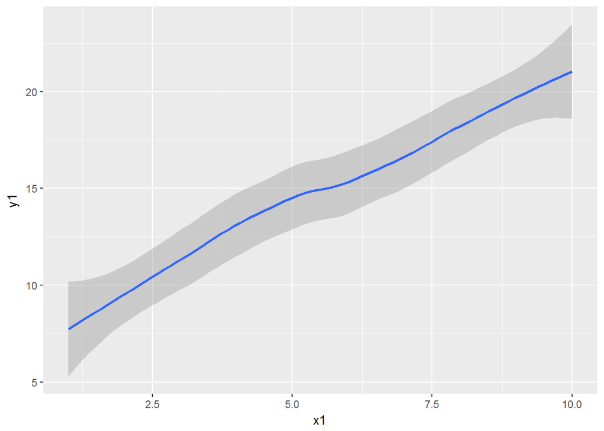

```r
sim1a <- tibble(
  x1 = rep(1:10, each = 3),
  y1 = x1 * 1.5 + 6 + rt(length(x1), df = 2)
)

sim1a %>% ggplot(mapping = aes(x= x1,y= y1)) + geom_smooth()
```

```r
set.seed(100)
(sim1a_mutated <- sim1a %>% mutate(Id = row_number()))
```

```
## # A tibble: 30 x 3
##       x1    y1    Id
##    <int> <dbl> <int>
##  1     1  9.77     1
##  2     1  7.96     2
##  3     1  7.58     3
##  4     2  9.02     4
##  5     2  7.40     5
##  6     2  9.25     6
##  7     3 10.5      7
##  8     3  9.31     8
##  9     3 10.2      9
## 10     4 10.3     10
## # ... with 20 more rows
```

```r
train_set <- sim1a_mutated %>% sample_frac(0.7)
test_set <- sim1a_mutated%>% filter(!( Id %in% train_set$Id))

mod <- lm(y1 ~ x1, data = train_set)
tidy(mod)
```

```
##          term estimate std.error statistic      p.value
## 1 (Intercept) 6.419850 1.1045364  5.812257 1.340505e-05
## 2          x1 1.460534 0.1854435  7.875896 2.112378e-07
```

```r
glance(mod)
```

```
##   r.squared adj.r.squared    sigma statistic      p.value df    logLik
## 1 0.7655182      0.753177 2.482714  62.02974 2.112378e-07  2 -47.84323
##        AIC    BIC deviance df.residual
## 1 101.6865 104.82 117.1135          19
```

```r
test_mod <- predict(mod, newdata = test_set)
(rmse <- sqrt(mean((test_set$y1 - test_mod)^2)))
```

```
## [1] 1.542766
```